# **Navigation Dataset**

## **Importing Python Libraries 📕 📗 📘 📙**

```python
import numpy as np
import pandas as pd
from sklearn import preprocessing
import seaborn as sns
from pylab import plot, show
import matplotlib.pyplot as plt
plt.style.use('ggplot')
from sklearn.feature_selection import VarianceThreshold
from sklearn.feature_selection import SelectKBest
from sklearn.feature_selection import chi2
from sklearn.feature_selection import f_classif
from sklearn.feature_selection import mutual_info_classif
from sklearn.svm import LinearSVC
from sklearn.feature_selection import SelectFromModel
from sklearn.ensemble import ExtraTreesClassifier
from sklearn.utils import shuffle
from sklearn.preprocessing import LabelEncoder
from sklearn.preprocessing import MinMaxScaler
from sklearn.tree import DecisionTreeClassifier

import warnings
warnings.filterwarnings("ignore")
```

## **Loading the dataset**

```python
data = pd.read_csv('Navigation_Dataset.csv', error_bad_lines = False)
data1=data.copy()
```

## **Exploratory Data Analysis**

# Five top records of data

```python
data.head()
```

|  | foresee_respondent | foresee_session_id | wt_visitor_id | day | Survey_Category | Product | Platform | main_task | CSAT | TA | ... | page_loads | link_clicks | impressions | urls | Searches | Page Events | Page Views | Average Page Depth | Reloads | Time Spent per Visit (seconds) |
| --- | --- | --- | --- | --- | --- | --- | --- | --- | --- | --- | --- | --- | --- | --- | --- | --- | --- | --- | --- | --- | --- |
| 0 | axg6v1l5DA7iV2mItNiXZXIt1NwbFFzV | 03aa8b78-4758-4fde-8260-10924007c86d | 7.413472e+09 | 11/6/21 | Account Management | DTV | App | Set up or manage Access ID/website profile (in... | 66.67 | No | ... | 60.0 | 22.0 | 3.0 | , /acctmgmt/fpwd/createnewpwd, /my/virtual/alr... | 0.0 | 21.0 | 13.0 | 65.0 | 1.0 | 217.0 |
| 1 | AxMp11NgEd5gUQQk5tZppQ4C | 08ecdb46-47c4-4d40-bbbc-dbeee788e0f5 | 7.690689e+09 | 1/17/22 | Account Management | Wireless | Desktop | Other | 0.00 | No | ... | 11.0 | 14.0 | 9.0 | /acctmgmt/accountoverview, /acctmgmt/wireless/... | NaN | NaN | NaN | NaN | NaN | NaN |
| 2 | c5odUJVxxMVBldAkEhdEIw4C | 10d32120-8023-4720-8bdb-e63f57e99d65 | 6.756765e+09 | 12/12/21 | Account Management | Other | Desktop | Add, change or downgrade plans and features (e... | 0.00 | No | ... | 3.0 | 3.0 | 5.0 | /support/, /support/contact-us/ | NaN | NaN | NaN | NaN | NaN | NaN |
| 3 | IMAyzf8pTFEiuRdoBZSPNnhnqEnzn5YP | 208b4dd7-a0fd-40c3-b44e-84ff3be1f46b | 7.570705e+09 | 1/14/22 | Account Management | BB | App | Check usage | 88.89 | No | ... | 13.0 | 7.0 | 15.0 | /virtual/nativemorenav, /acctmgmt/billandpay/h... | NaN | NaN | NaN | NaN | NaN | NaN |
| 4 | v7LSG4RWKj40pIUyRmIp3Z1BEb5FAo2k | 290bf194-6762-44bd-8aad-8027a4f358c1 | 7.138217e+09 | 1/18/22 | Account Management | Wireless | App | Make a payment | 22.22 | No | ... | 7.0 | 2.0 | 2.0 | /support/article/, /acctmgmt/makepayment/payme... | NaN | NaN | NaN | NaN | NaN | NaN |

5 rows × 26 columns

# Five last records of data

```python
data.tail()
```

|  | foresee_respondent | foresee_session_id | wt_visitor_id | day | Survey_Category | Product | Platform | main_task | CSAT | TA | ... | page_loads | link_clicks | impressions | urls | Searches | Page Events | Page Views | Average Page Depth | Reloads | Time Spent per Visit (seconds) |
| --- | --- | --- | --- | --- | --- | --- | --- | --- | --- | --- | --- | --- | --- | --- | --- | --- | --- | --- | --- | --- | --- |
| 136157 | IdrlX4UqQ51O0FwZFf77EM1IaXx2Xfe0 | e3b28f7f-1ac2-42f2-92f6-418964e27c6c | 7.494885e+09 | 11/14/21 | Account Management | Wireless | App | Make a payment arrangement | 100.00 | Yes | ... | 4.0 | 2.0 | 1.0 | /support/article/, /outages/, /support/contact... | NaN | NaN | NaN | NaN | NaN | NaN |
| 136158 | 8Qq8nWgQGPAN5t9dtjOpdYKwNm9Nlba0 | e3d52b6a-170f-47b9-9d0d-a109a0b82074 | 7.543572e+09 | 12/12/21 | Account Management | WatchTV | App | Set up/activate products or services | 0.00 | No | ... | 19.0 | 17.0 | 2.0 | /search, /my/virtual/cbowelcome, /my/virtual/a... | 0.0 | 1.0 | 1.0 | 85.0 | 0.0 | 1.0 |
| 136159 | AsJI4tMAhoRoBAtBQ4c9JA4C | e4fe8c44-e26e-4e40-98f5-141d531cec99 | 7.617050e+09 | 12/3/21 | Account Management | BB | Desktop | Make a payment | 0.00 | Yes | ... | 10.0 | 18.0 | 6.0 | /my/virtual/cancelautopay/modal, /acctmgmt/acc... | NaN | NaN | NaN | NaN | NaN | NaN |
| 136160 | gHBcqzeCOezhXLMmnumi3sbfpwYYV8ag | f25d495e-e6e0-444c-a5a4-1caac9e2cd45 | 7.103805e+09 | 12/12/21 | Account Management | Wireless | App | Enroll/unenroll in AutoPay | 0.00 | No | ... | 2.0 | 0.0 | 0.0 | /my/virtual/autopaypaperlessdashboard | NaN | NaN | NaN | NaN | NaN | NaN |
| 136161 | Lm1sS38GnswyOv80uIggSsZxW09riqFH | f32e293b-600a-43ec-969f-8f2c070ffaf2 | 7.627227e+09 | 12/8/21 | Account Management | Wireless | Mobile Web | Make a payment | 92.59 | Yes | ... | 22.0 | 16.0 | 6.0 | , /acctmgmt/makepayment, /acctmgmt/accountover... | NaN | NaN | NaN | NaN | NaN | NaN |

5 rows × 26 columns

# Coloumns/features in data

```python
data.columns
```

```
Index(['foresee_respondent', 'foresee_session_id', 'wt_visitor_id', 'day',
       'Survey_Category', 'Product', 'Platform', 'main_task', 'CSAT', 'TA',
       'Effort', 'Navigation_Difficulties', 'Relevance', 'called_flag',
       'app_session_id', 'event_count', 'page_loads', 'link_clicks',
       'impressions', 'urls', 'Searches', 'Page Events', 'Page Views',
       'Average Page Depth', 'Reloads', 'Time Spent per Visit (seconds)'],
      dtype='object')
```

# Length of data

```python
print('lenght of data is', len(data))
```

```
lenght of data is 136162
```

# Shape of data

```python
data.shape
```

```
(136162, 26)
```

# Data information

```python
data.info()
```

```
<class 'pandas.core.frame.DataFrame'>
RangeIndex: 136162 entries, 0 to 136161
Data columns (total 26 columns):
 #   Column                          Non-Null Count   Dtype
---  ------                          --------------   -----
 0   foresee_respondent              136162 non-null  object
 1   foresee_session_id              136155 non-null  object
 2   wt_visitor_id                   135230 non-null  float64
 3   day                             136162 non-null  object
 4   Survey_Category                 136162 non-null  object
 5   Product                         136162 non-null  object
 6   Platform                        136162 non-null  object
 7   main_task                       136162 non-null  object
 8   CSAT                            136162 non-null  float64
 9   TA                              136162 non-null  object
```

[output cut: 18 more lines]

# Data types of all coloumns

```python
data.dtypes
```

```
foresee_respondent                 object
foresee_session_id                 object
wt_visitor_id                     float64
day                                object
Survey_Category                    object
Product                            object
Platform                           object
main_task                          object
CSAT                              float64
TA                                 object
Effort                              int64
Navigation_Difficulties            object
Relevance                           int64
called_flag                         int64
app_session_id                     object
event_count                       float64
page_loads                        float64
link_clicks                       float64
impressions                       float64
urls                               object
Searches                          float64
Page Events                       float64
Page Views                        float64
Average Page Depth                float64
Reloads                           float64
Time Spent per Visit (seconds)    float64
dtype: object
```

# Checking Null Values

```python
data[data.isnull().any(axis=1)].head()
```

|  | foresee_respondent | foresee_session_id | wt_visitor_id | day | Survey_Category | Product | Platform | main_task | CSAT | TA | ... | page_loads | link_clicks | impressions | urls | Searches | Page Events | Page Views | Average Page Depth | Reloads | Time Spent per Visit (seconds) |
| --- | --- | --- | --- | --- | --- | --- | --- | --- | --- | --- | --- | --- | --- | --- | --- | --- | --- | --- | --- | --- | --- |
| 1 | AxMp11NgEd5gUQQk5tZppQ4C | 08ecdb46-47c4-4d40-bbbc-dbeee788e0f5 | 7.690689e+09 | 1/17/22 | Account Management | Wireless | Desktop | Other | 0.00 | No | ... | 11.0 | 14.0 | 9.0 | /acctmgmt/accountoverview, /acctmgmt/wireless/... | NaN | NaN | NaN | NaN | NaN | NaN |
| 2 | c5odUJVxxMVBldAkEhdEIw4C | 10d32120-8023-4720-8bdb-e63f57e99d65 | 6.756765e+09 | 12/12/21 | Account Management | Other | Desktop | Add, change or downgrade plans and features (e... | 0.00 | No | ... | 3.0 | 3.0 | 5.0 | /support/, /support/contact-us/ | NaN | NaN | NaN | NaN | NaN | NaN |
| 3 | IMAyzf8pTFEiuRdoBZSPNnhnqEnzn5YP | 208b4dd7-a0fd-40c3-b44e-84ff3be1f46b | 7.570705e+09 | 1/14/22 | Account Management | BB | App | Check usage | 88.89 | No | ... | 13.0 | 7.0 | 15.0 | /virtual/nativemorenav, /acctmgmt/billandpay/h... | NaN | NaN | NaN | NaN | NaN | NaN |
| 4 | v7LSG4RWKj40pIUyRmIp3Z1BEb5FAo2k | 290bf194-6762-44bd-8aad-8027a4f358c1 | 7.138217e+09 | 1/18/22 | Account Management | Wireless | App | Make a payment | 22.22 | No | ... | 7.0 | 2.0 | 2.0 | /support/article/, /acctmgmt/makepayment/payme... | NaN | NaN | NaN | NaN | NaN | NaN |
| 5 | YwBsUMV1k00wxgZAwYNlxA4C | 3db9540a-963a-41c7-ab7d-4d3757526803 | 7.715207e+09 | 1/25/22 | Support | Other services from AT&T (Home phone, DSL, etc.) | Desktop | Troubleshooting - fix a problem with my device... | 88.89 | Yes | ... | 8.0 | 15.0 | 10.0 | /support/gatewayrestartcomplete/modal, /outage... | NaN | NaN | NaN | NaN | NaN | NaN |

5 rows × 26 columns

# Filling the missing values with 0

```python
data=data.fillna(0)
```

# Length of the data

```python
len(data)
```

```
136162
```

# Data Description

```python
data.describe()
```

|  | wt_visitor_id | CSAT | Effort | Relevance | called_flag | event_count | page_loads | link_clicks | impressions | Searches | Page Events | Page Views | Average Page Depth | Reloads | Time Spent per Visit (seconds) |
| --- | --- | --- | --- | --- | --- | --- | --- | --- | --- | --- | --- | --- | --- | --- | --- |
| count | 1.361620e+05 | 136162.000000 | 136162.000000 | 136162.000000 | 136162.000000 | 136162.000000 | 136162.000000 | 136162.000000 | 136162.000000 | 136162.000000 | 136162.000000 | 136162.000000 | 136162.000000 | 136162.000000 | 136162.000000 |
| mean | 7.090134e+09 | 46.672822 | 5.177384 | 5.261652 | 0.142242 | 34.585758 | 9.409725 | 7.869090 | 4.953357 | 0.143417 | 5.919118 | 2.416754 | 5.101092 | 0.458909 | 154.872714 |
| std | 1.076364e+09 | 39.416086 | 3.514972 | 3.451208 | 0.349300 | 197.624714 | 25.106801 | 10.704511 | 7.772310 | 9.012269 | 31.604904 | 12.376229 | 15.611343 | 8.782609 | 623.411987 |
| min | 0.000000e+00 | 0.000000 | 1.000000 | 1.000000 | 0.000000 | 0.000000 | 0.000000 | 0.000000 | 0.000000 | 0.000000 | 0.000000 | 0.000000 | 0.000000 | 0.000000 | 0.000000 |
| 25% | 7.032914e+09 | 0.000000 | 1.000000 | 1.000000 | 0.000000 | 12.000000 | 3.000000 | 1.000000 | 0.000000 | 0.000000 | 0.000000 | 0.000000 | 0.000000 | 0.000000 | 0.000000 |
| 50% | 7.571683e+09 | 44.440000 | 5.000000 | 5.000000 | 0.000000 | 22.000000 | 6.000000 | 4.000000 | 3.000000 | 0.000000 | 0.000000 | 0.000000 | 0.000000 | 0.000000 | 0.000000 |
| 75% | 7.645310e+09 | 88.890000 | 9.000000 | 9.000000 | 0.000000 | 42.000000 | 12.000000 | 11.000000 | 6.000000 | 0.000000 | 0.000000 | 0.000000 | 0.000000 | 0.000000 | 0.000000 |
| max | 7.801022e+09 | 100.000000 | 10.000000 | 10.000000 | 1.000000 | 49757.000000 | 4544.000000 | 337.000000 | 216.000000 | 2225.000000 | 2430.000000 | 1817.000000 | 982.000000 | 1815.000000 | 42834.000000 |

# Rows and columns in the dataset

```python
print('Count of columns in the data is:  ', len(data.columns))
```

```
Count of columns in the data is:   26
```

```python
print('Count of rows in the data is:  ', len(data))
```

```
Count of rows in the data is:   136162
```

# Data information with memory usage

```python
data.info()
```

```
<class 'pandas.core.frame.DataFrame'>
RangeIndex: 136162 entries, 0 to 136161
Data columns (total 26 columns):
 #   Column                          Non-Null Count   Dtype
---  ------                          --------------   -----
 0   foresee_respondent              136162 non-null  object
 1   foresee_session_id              136162 non-null  object
 2   wt_visitor_id                   136162 non-null  float64
 3   day                             136162 non-null  object
 4   Survey_Category                 136162 non-null  object
 5   Product                         136162 non-null  object
 6   Platform                        136162 non-null  object
 7   main_task                       136162 non-null  object
 8   CSAT                            136162 non-null  float64
 9   TA                              136162 non-null  object
```

[output cut: 18 more lines]

# Memory Usage

```python
current_memory_usage = data.memory_usage().sum()
```

# Changing the Features types to decrease the memory usage

```python
integer = []
floatt = []
cat=[]
for integerr in data.columns[:-1]:
    if data[integerr].dtype == "int64": integer.append(integerr)
    elif data[integerr].dtype == "float64": floatt.append(integerr)
    elif data[integerr].dtype == "object": cat.append(integerr)


data[integer] = data[integer].astype("int32")
data[floatt] = data[floatt].astype("float32")
```

# Data information with memory now

```python
data.info()
```

```
<class 'pandas.core.frame.DataFrame'>
RangeIndex: 136162 entries, 0 to 136161
Data columns (total 26 columns):
 #   Column                          Non-Null Count   Dtype
---  ------                          --------------   -----
 0   foresee_respondent              136162 non-null  object
 1   foresee_session_id              136162 non-null  object
 2   wt_visitor_id                   136162 non-null  float32
 3   day                             136162 non-null  object
 4   Survey_Category                 136162 non-null  object
 5   Product                         136162 non-null  object
 6   Platform                        136162 non-null  object
 7   main_task                       136162 non-null  object
 8   CSAT                            136162 non-null  float32
 9   TA                              136162 non-null  object
```

[output cut: 18 more lines]

```python
now_memory_usage = data.memory_usage().sum()
previous_vs_now = (current_memory_usage - now_memory_usage) / current_memory_usage * 100
print(f"%{previous_vs_now} is lower memory usage")
```

```
%26.922955244690456 is lower memory usage
```

# Deleting the duplicate rows

```python
current=len(data)
print('Rows of data before Delecting ', current)

data=data.drop_duplicates()

now=len(data)
print('Rows of data before Delecting ', now)

diff=current-now
print('Duplicated rows deleted ', diff)
```

```
Rows of data before Delecting  136162
Rows of data before Delecting  136162
Duplicated rows deleted  0
```

## **Preparing the Dataset**

### To make it Sure if there is any NaN values, Infinity values

```python
data = data[~data.isin([np.nan, np.inf, -np.inf]).any(1)]
```

```python
data.info()
```

```
<class 'pandas.core.frame.DataFrame'>
Int64Index: 136162 entries, 0 to 136161
Data columns (total 26 columns):
 #   Column                          Non-Null Count   Dtype
---  ------                          --------------   -----
 0   foresee_respondent              136162 non-null  object
 1   foresee_session_id              136162 non-null  object
 2   wt_visitor_id                   136162 non-null  float32
 3   day                             136162 non-null  object
 4   Survey_Category                 136162 non-null  object
 5   Product                         136162 non-null  object
 6   Platform                        136162 non-null  object
 7   main_task                       136162 non-null  object
 8   CSAT                            136162 non-null  float32
 9   TA                              136162 non-null  object
```

[output cut: 18 more lines]

As we can see that the day column is of object data type means it's a string. Now let's convert it into date format.

```python
data["Date"] = pd.to_datetime(data["day"], format = "%m/%d/%y")
```

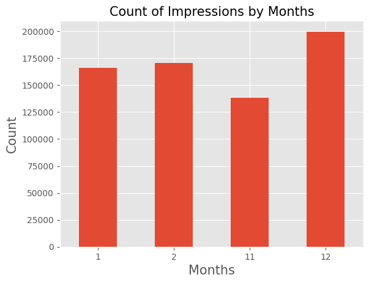

```python
month = data["Date"].dt.month
data.groupby(month)["impressions"].sum().plot(kind = "bar")
plt.xticks(rotation = 0)
plt.xlabel("Months", fontsize = 15)
plt.ylabel("Count", fontsize = 15)
plt.title("Count of Impressions by Months", fontsize = 15);
```

The above bar plot shows us that 12th months has the most number of impressions followed by 2nd, 1st and 11th month.

```python
year = data["Date"].dt.year
impressions_by_year = data.groupby(year)["impressions"].sum()
impressions_by_year
```

```
Date
2021    337915.0
2022    336544.0
Name: impressions, dtype: float32
```

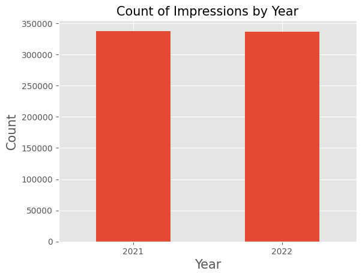

```python
impressions_by_year.plot(kind = "bar")
plt.xticks(rotation = 0)
plt.xlabel("Year", fontsize = 15)
plt.ylabel("Count", fontsize = 15)
plt.title("Count of Impressions by Year", fontsize = 15);
```

The above plot shows us that both years have almost same number of impressions but if we check the count of both year then 2021 has more number of expressions.

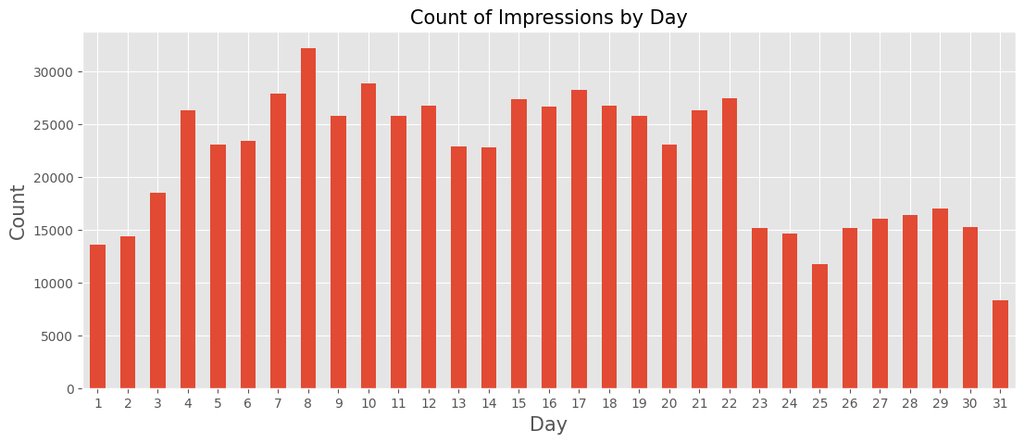

```python
day = data["Date"].dt.day
plt.figure(figsize = [13, 5])
data.groupby(day)["impressions"].sum().plot(kind = "bar")
plt.xticks(rotation = 0);
plt.xlabel("Day", fontsize = 15)
plt.ylabel("Count", fontsize = 15)
plt.title("Count of Impressions by Day", fontsize = 15);
```

The above plot shows us that day 8 of the month has most number of impressions.

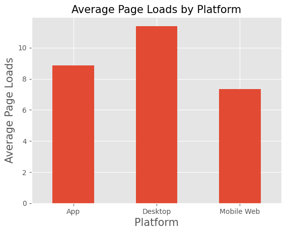

```python
data.groupby("Platform")["page_loads"].mean().plot(kind = "bar")
plt.xticks(rotation = 0)
plt.xlabel("Platform", fontsize = 15)
plt.ylabel("Average Page Loads", fontsize = 15)
plt.title("Average Page Loads by Platform", fontsize = 15);
```

We can clearly see that Desktop platform has most page loads on average

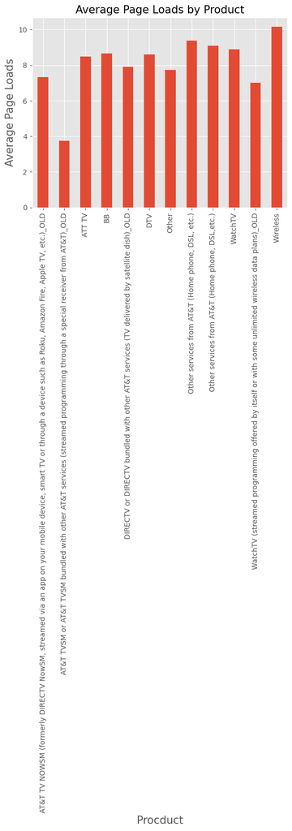

```python
data.groupby("Product")["page_loads"].mean().plot(kind = "bar")
# plt.xticks(rotation = 0)
plt.xlabel("Procduct", fontsize = 15)
plt.ylabel("Average Page Loads", fontsize = 15)
plt.title("Average Page Loads by Product", fontsize = 15);
```

Wireless products have the most page loads on average

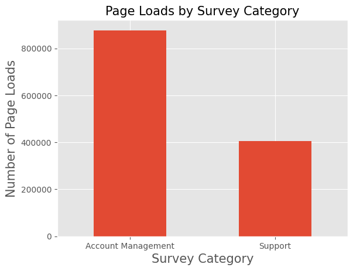

```python
data.groupby("Survey_Category")["page_loads"].sum().plot(kind = "bar")
plt.xticks(rotation = 0)
plt.xlabel("Survey Category", fontsize = 15)
plt.ylabel("Number of Page Loads", fontsize = 15)
plt.title("Page Loads by Survey Category", fontsize = 15);
```

Account Management as a Survey Category has the most page loads

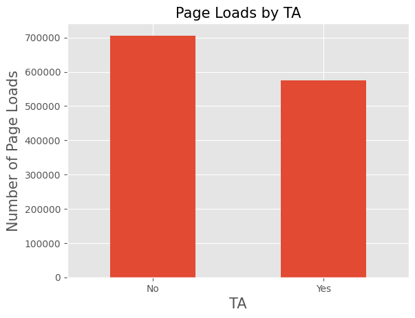

```python
data.groupby("TA")["page_loads"].sum().plot(kind = "bar")
plt.xticks(rotation = 0)
plt.xlabel("TA", fontsize = 15)
plt.ylabel("Number of Page Loads", fontsize = 15)
plt.title("Page Loads by TA", fontsize = 15);
```

```python
len(data["urls"].unique())
```

```
92361
```

```python
data["Effort"].unique()
```

```
array([ 5,  1,  8,  9,  7, 10,  3,  6,  4,  2])
```

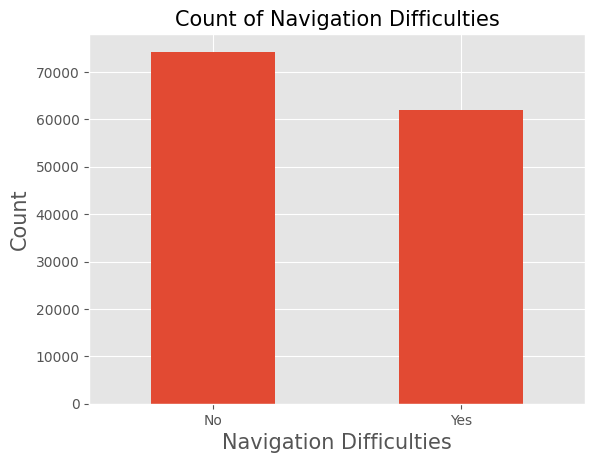

```python
data["Navigation_Difficulties"].value_counts().plot(kind = "bar")
plt.xticks(rotation = 0)
plt.xlabel("Navigation Difficulties", fontsize = 15)
plt.ylabel("Count", fontsize = 15)
plt.title("Count of Navigation Difficulties", fontsize = 15);
```

We can clearly see that majority of the users did not face any difficulty in navigating.

### Encoding the features from categorical data type to numric form for the features selection

```python
encoder={}
for col in data.columns:
    data[col]=data[col].astype(str)
    encoder[col]=LabelEncoder()
    data[col]=encoder[col].fit_transform(data[col])
data=data.sample(1000)
```

# **Feature Selection Techniques and Methods**

### Univariate feature selection

- using mutual_info_classif technique to extrcat the most useful features from the data

```python
X=data.drop(columns=['TA'])
y=data['TA']
MiC_M= SelectKBest(mutual_info_classif, k=15)
MiC_M.fit(X, y)
MiC_features = MiC_M.transform(X)
```

```python
feature_names = list(X.columns[MiC_M.get_support(indices=True)])
MiC_features=pd.DataFrame(MiC_features)
MiC_features.columns=feature_names
MiC_features.head()
```

|  | Survey_Category | Product | CSAT | Effort | Navigation_Difficulties | Relevance | app_session_id | event_count | page_loads | impressions | Searches | Page Views | Average Page Depth | Reloads | Date |
| --- | --- | --- | --- | --- | --- | --- | --- | --- | --- | --- | --- | --- | --- | --- | --- |
| 0 | 0 | 11 | 1 | 8 | 0 | 9 | 53495 | 426 | 37 | 136 | 0 | 0 | 0 | 0 | 69 |
| 1 | 0 | 11 | 2 | 4 | 1 | 3 | 111379 | 363 | 152 | 125 | 0 | 0 | 0 | 0 | 41 |
| 2 | 1 | 3 | 7 | 8 | 1 | 7 | 85898 | 517 | 67 | 55 | 0 | 0 | 0 | 0 | 16 |
| 3 | 1 | 11 | 7 | 7 | 1 | 3 | 109162 | 240 | 152 | 103 | 0 | 0 | 0 | 0 | 91 |
| 4 | 1 | 11 | 1 | 1 | 0 | 1 | 61357 | 77 | 126 | 0 | 0 | 0 | 0 | 0 | 18 |

```python
#These features are selected
list(MiC_features.columns)
```

```
['Survey_Category',
 'Product',
 'CSAT',
 'Effort',
 'Navigation_Difficulties',
 'Relevance',
 'app_session_id',
 'event_count',
 'page_loads',
 'impressions',
 'Searches',
 'Page Views',
 'Average Page Depth',
 'Reloads',
 'Date']
```

```python
MiC_features=pd.DataFrame(MiC_features)
MiC_features.shape[1]  #Features count
```

```
15
```

### Univariate feature selection

- using f_classif technique to extrcat the most useful features from the data

```python
FCF_M= SelectKBest(f_classif, k=15)
FCF_M.fit(X, y)
FCF_features = FCF_M.transform(X)
```

```python
feature_names = list(X.columns[FCF_M.get_support(indices=True)])
FCF_features=pd.DataFrame(FCF_features)
FCF_features.columns=feature_names
FCF_features.head()
```

|  | Survey_Category | Product | CSAT | Effort | Navigation_Difficulties | Relevance | event_count | page_loads | link_clicks | impressions | urls | Page Events | Page Views | Average Page Depth | Reloads |
| --- | --- | --- | --- | --- | --- | --- | --- | --- | --- | --- | --- | --- | --- | --- | --- |
| 0 | 0 | 11 | 1 | 8 | 0 | 9 | 426 | 37 | 31 | 136 | 20153 | 0 | 0 | 0 | 0 |
| 1 | 0 | 11 | 2 | 4 | 1 | 3 | 363 | 152 | 13 | 125 | 91763 | 0 | 0 | 0 | 0 |
| 2 | 1 | 3 | 7 | 8 | 1 | 7 | 517 | 67 | 57 | 55 | 88244 | 0 | 0 | 0 | 0 |
| 3 | 1 | 11 | 7 | 7 | 1 | 3 | 240 | 152 | 138 | 103 | 88803 | 0 | 0 | 0 | 0 |
| 4 | 1 | 11 | 1 | 1 | 0 | 1 | 77 | 126 | 57 | 0 | 64408 | 0 | 0 | 0 | 0 |

```python
#These features are selected
list(FCF_features.columns)
```

```
['Survey_Category',
 'Product',
 'CSAT',
 'Effort',
 'Navigation_Difficulties',
 'Relevance',
 'event_count',
 'page_loads',
 'link_clicks',
 'impressions',
 'urls',
 'Page Events',
 'Page Views',
 'Average Page Depth',
 'Reloads']
```

```python
FCF_features=pd.DataFrame(FCF_features)
FCF_features.shape[1]  #Features count
```

```
15
```

### Univariate feature selection

- using chi2 technique to extrcat the most useful features from the data

```python
C_M= SelectKBest(chi2, k=15)
C_M.fit(X, y)
C_features = C_M.transform(X)
```

```python
feature_names = list(X.columns[C_M.get_support(indices=True)])
C_features=pd.DataFrame(C_features)
C_features.columns=feature_names
C_features.head()
```

|  | foresee_respondent | foresee_session_id | wt_visitor_id | CSAT | Effort | Relevance | app_session_id | event_count | link_clicks | urls | Page Events | Page Views | Average Page Depth | Reloads | Time Spent per Visit (seconds) |
| --- | --- | --- | --- | --- | --- | --- | --- | --- | --- | --- | --- | --- | --- | --- | --- |
| 0 | 91394 | 63129 | 103205 | 1 | 8 | 9 | 53495 | 426 | 31 | 20153 | 0 | 0 | 0 | 0 | 0 |
| 1 | 36966 | 65715 | 87921 | 2 | 4 | 3 | 111379 | 363 | 13 | 91763 | 0 | 0 | 0 | 0 | 0 |
| 2 | 29889 | 71030 | 69731 | 7 | 8 | 7 | 85898 | 517 | 57 | 88244 | 0 | 0 | 0 | 0 | 0 |
| 3 | 112829 | 7963 | 71339 | 7 | 7 | 3 | 109162 | 240 | 138 | 88803 | 0 | 0 | 0 | 0 | 0 |
| 4 | 26404 | 110135 | 44019 | 1 | 1 | 1 | 61357 | 77 | 57 | 64408 | 0 | 0 | 0 | 0 | 0 |

```python
#These features are selected
list(C_features.columns)
```

```
['foresee_respondent',
 'foresee_session_id',
 'wt_visitor_id',
 'CSAT',
 'Effort',
 'Relevance',
 'app_session_id',
 'event_count',
 'link_clicks',
 'urls',
 'Page Events',
 'Page Views',
 'Average Page Depth',
 'Reloads',
 'Time Spent per Visit (seconds)']
```

```python
C_features=pd.DataFrame(C_features)
C_features.shape[1]  #Features count
```

```
15
```

### Feature selection using SelectFromModel

```python
#by using the SVM L1 based features, we selected most useful features
L_svc = LinearSVC(C=0.01, penalty="l2", dual=False).fit(X, y)
L_svc = SelectFromModel(L_svc, prefit=True)
L_svc_Features = L_svc.transform(X)
```

```python
feature_names = list(X.columns[L_svc.get_support(indices=True)])
L_svc_Features=pd.DataFrame(L_svc_Features)
L_svc_Features.columns=feature_names
L_svc_Features.head()
```

|  | Survey_Category | Product | CSAT | Effort | Navigation_Difficulties | Relevance | Searches |
| --- | --- | --- | --- | --- | --- | --- | --- |
| 0 | 0 | 11 | 1 | 8 | 0 | 9 | 0 |
| 1 | 0 | 11 | 2 | 4 | 1 | 3 | 0 |
| 2 | 1 | 3 | 7 | 8 | 1 | 7 | 0 |
| 3 | 1 | 11 | 7 | 7 | 1 | 3 | 0 |
| 4 | 1 | 11 | 1 | 1 | 0 | 1 | 0 |

```python
#These features are selected
list(L_svc_Features.columns)
```

```
['Survey_Category',
 'Product',
 'CSAT',
 'Effort',
 'Navigation_Difficulties',
 'Relevance',
 'Searches']
```

```python
L_svc_Features.shape[1]  #Features count
```

```
7
```

### Feature selection using SelectFromModel

- Tree-based feature selection

```python
ETC_M = ExtraTreesClassifier(n_estimators=40)
ETC_M.fit(X, y)
ETC_M = SelectFromModel(ETC_M, prefit=True)
ETC_M_Features = ETC_M.transform(X)
```

```python
feature_names = list(X.columns[ETC_M.get_support(indices=True)])
ETC_M_Features=pd.DataFrame(ETC_M_Features)
ETC_M_Features.columns=feature_names
ETC_M_Features.head()
```

|  | Survey_Category | CSAT | Effort | Navigation_Difficulties | Relevance |
| --- | --- | --- | --- | --- | --- |
| 0 | 0 | 1 | 8 | 0 | 9 |
| 1 | 0 | 2 | 4 | 1 | 3 |
| 2 | 1 | 7 | 8 | 1 | 7 |
| 3 | 1 | 7 | 7 | 1 | 3 |
| 4 | 1 | 1 | 1 | 0 | 1 |

```python
#These features are selected
list(ETC_M_Features.columns)
```

```
['Survey_Category', 'CSAT', 'Effort', 'Navigation_Difficulties', 'Relevance']
```

```python
ETC_M_Features.shape[1]  #Features count
```

```
5
```

# **Hybrid Feature Selection**

- We are going to combine all the features that are selected using differenet techniques

```python
Hybrid_Features=pd.concat([MiC_features, FCF_features, C_features, L_svc_Features, ETC_M_Features], axis=1)
#drop all those features
Hybrid_Features = Hybrid_Features.loc[:,~Hybrid_Features.columns.duplicated()]
```

```python
Hybrid_Features.shape[1]  #Features count
```

```
22
```

```python
list(Hybrid_Features.columns)
```

```
['Survey_Category',
 'Product',
 'CSAT',
 'Effort',
 'Navigation_Difficulties',
 'Relevance',
 'app_session_id',
 'event_count',
 'page_loads',
 'impressions',
 'Searches',
 'Page Views',
 'Average Page Depth',
 'Reloads',
 'Date',
 'link_clicks',
 'urls',
 'Page Events',
 'foresee_respondent',
 'foresee_session_id',
 'wt_visitor_id',
 'Time Spent per Visit (seconds)']
```

## Correlation of Features

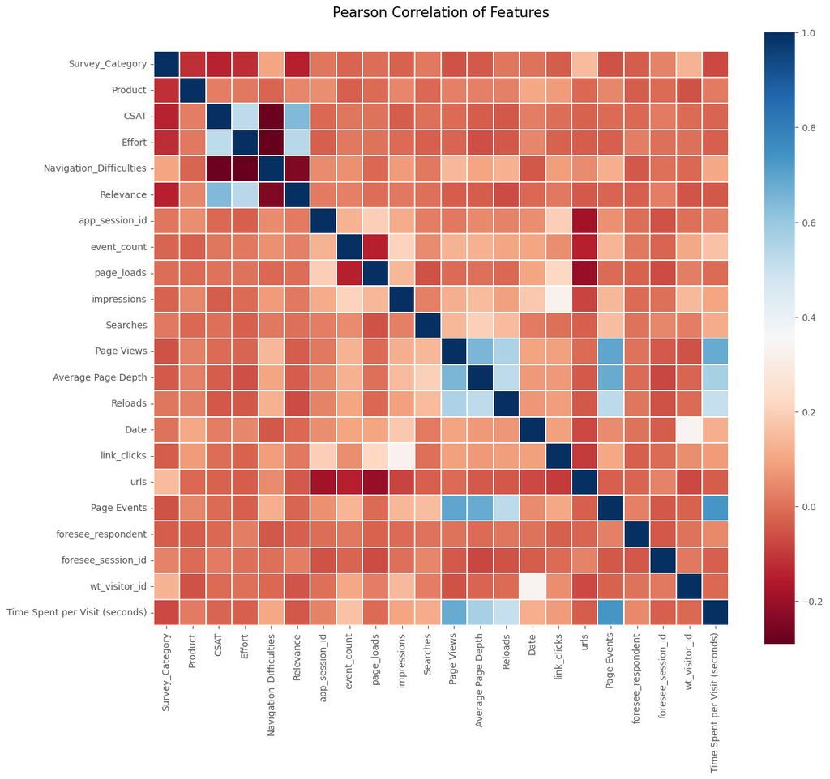

```python
colormap = plt.cm.RdBu
plt.figure(figsize=(14,12))
plt.title('Pearson Correlation of Features', y=1.05, size=15)
sns.heatmap(Hybrid_Features.corr(),linewidths=0.1,vmax=1.0,
            square=True, cmap=colormap, linecolor='white')
```

### Page loads with respect to URL's

> Double click on the plot and check the range of URLS with respect to the count of page loads

```python
plt.figure(figsize=(20,20))
g = sns.FacetGrid(data, col='page_loads')
g.map(plt.hist, 'urls', bins=20)
```

[figure not shown]

```python
data.columns
```

```
Index(['foresee_respondent', 'foresee_session_id', 'wt_visitor_id', 'day',
       'Survey_Category', 'Product', 'Platform', 'main_task', 'CSAT', 'TA',
       'Effort', 'Navigation_Difficulties', 'Relevance', 'called_flag',
       'app_session_id', 'event_count', 'page_loads', 'link_clicks',
       'impressions', 'urls', 'Searches', 'Page Events', 'Page Views',
       'Average Page Depth', 'Reloads', 'Time Spent per Visit (seconds)',
       'Date'],
      dtype='object')
```

## Correlation of task accomplishment with page_loads

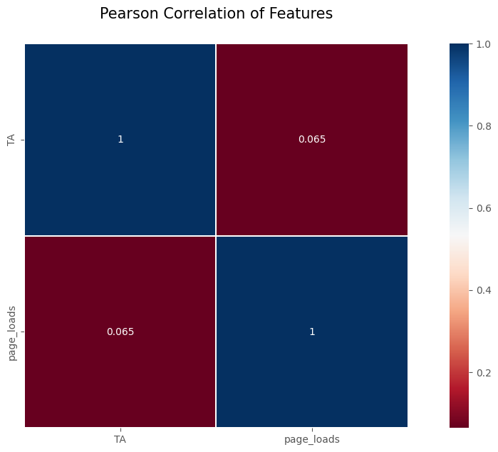

```python
cols=['TA','page_loads']
cols=data[cols]
colormap = plt.cm.RdBu
plt.figure(figsize=(15,7))
plt.title('Pearson Correlation of Features', y=1.05, size=15)
sns.heatmap(cols.corr(),linewidths=0.1,vmax=1.0,
            square=True, cmap=colormap, linecolor='white', annot=True)
```

```python
cols.corr()
```

|  | TA | page_loads |
| --- | --- | --- |
| TA | 1.000000 | 0.064548 |
| page_loads | 0.064548 | 1.000000 |

### Features Importance with respect to TA

```
No artists with labels found to put in legend.  Note that artists whose label start with an underscore are ignored when legend() is called with no argument.
```

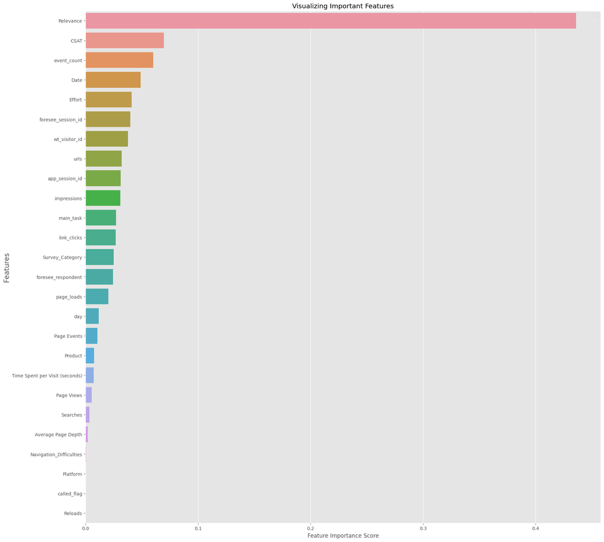

```python
X=data.drop(columns=['TA'])
y=data['TA']

rf = DecisionTreeClassifier()
rf.fit(X, y)
feature_imp = pd.Series(rf.feature_importances_,index=X.columns).sort_values(ascending=False)
plt.figure(figsize=(20, 20))
sns.barplot(x=feature_imp, y=feature_imp.index)
plt.xlabel('Feature Importance Score')
plt.ylabel('Features',fontsize=15)
plt.title("Visualizing Important Features")
plt.legend()
plt.show()
```

```python
feature_imp
```

```
Relevance                         0.436057
CSAT                              0.069706
event_count                       0.060188
Date                              0.049050
Effort                            0.040981
foresee_session_id                0.039858
wt_visitor_id                     0.037752
urls                              0.031975
app_session_id                    0.031246
impressions                       0.031022
main_task                         0.026965
link_clicks                       0.026816
Survey_Category                   0.024997
foresee_respondent                0.024333
page_loads                        0.020297
day                               0.011606
Page Events                       0.010644
Product                           0.007497
Time Spent per Visit (seconds)    0.007279
Page Views                        0.005593
Searches                          0.003589
Average Page Depth                0.002009
Navigation_Difficulties           0.000540
Platform                          0.000000
called_flag                       0.000000
Reloads                           0.000000
dtype: float64
```

### Features Importance with respect to page_loads

```
No artists with labels found to put in legend.  Note that artists whose label start with an underscore are ignored when legend() is called with no argument.
```

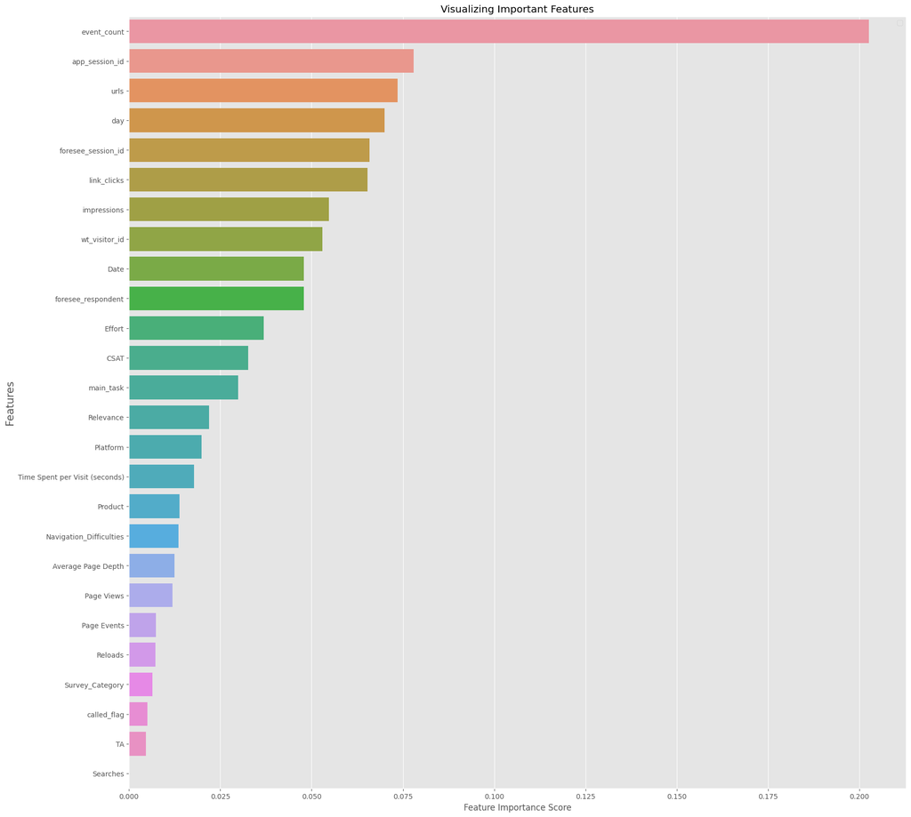

```python
X=data.drop(columns=['page_loads'])
y=data['page_loads']

rf = DecisionTreeClassifier()
rf.fit(X, y)
feature_imp = pd.Series(rf.feature_importances_,index=X.columns).sort_values(ascending=False)
plt.figure(figsize=(20, 20))
sns.barplot(x=feature_imp, y=feature_imp.index)
plt.xlabel('Feature Importance Score')
plt.ylabel('Features',fontsize=15)
plt.title("Visualizing Important Features")
plt.legend()
plt.show()
```

```python
feature_imp
```

```
event_count                       0.202656
app_session_id                    0.077949
urls                              0.073506
day                               0.070034
foresee_session_id                0.065901
link_clicks                       0.065250
impressions                       0.054768
wt_visitor_id                     0.053012
Date                              0.047882
foresee_respondent                0.047882
Effort                            0.036847
CSAT                              0.032625
main_task                         0.029876
Relevance                         0.021965
Platform                          0.019801
Time Spent per Visit (seconds)    0.017868
Product                           0.013776
Navigation_Difficulties           0.013566
Average Page Depth                0.012441
Page Views                        0.011909
Page Events                       0.007314
Reloads                           0.007188
Survey_Category                   0.006372
called_flag                       0.005035
TA                                0.004577
Searches                          0.000000
dtype: float64
```

```python
#feature correlation with TA and also one for navigation success
```

```
No artists with labels found to put in legend.  Note that artists whose label start with an underscore are ignored when legend() is called with no argument.
```

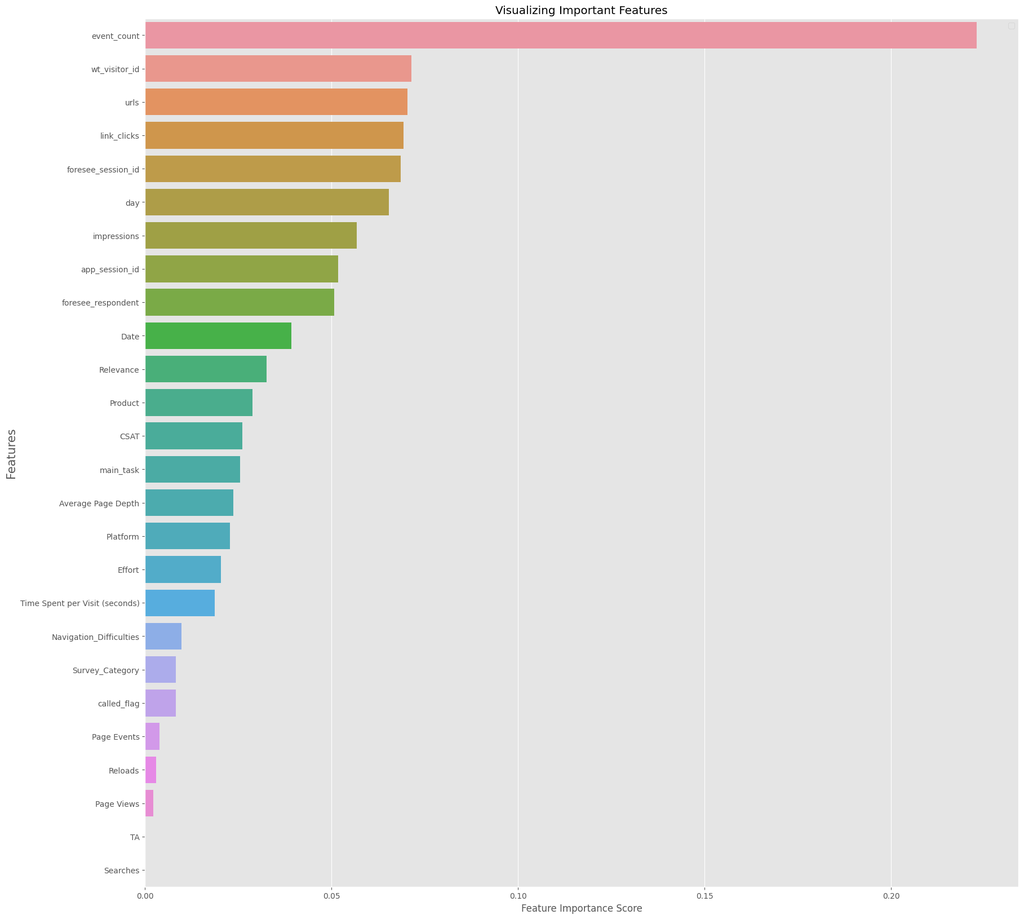

```python
data2=data[data1['TA']=='Yes']
X=data2.drop(columns=['page_loads'])
y=data2['page_loads']

rf = DecisionTreeClassifier()
rf.fit(X, y)
feature_imp = pd.Series(rf.feature_importances_,index=X.columns).sort_values(ascending=False)
plt.figure(figsize=(20, 20))
sns.barplot(x=feature_imp, y=feature_imp.index)
plt.xlabel('Feature Importance Score')
plt.ylabel('Features',fontsize=15)
plt.title("Visualizing Important Features")
plt.legend()
plt.show()
```

# Feature importance plot for decision tree model using the key features

### Features Importance with respect to Survey_Category

```
No artists with labels found to put in legend.  Note that artists whose label start with an underscore are ignored when legend() is called with no argument.
```

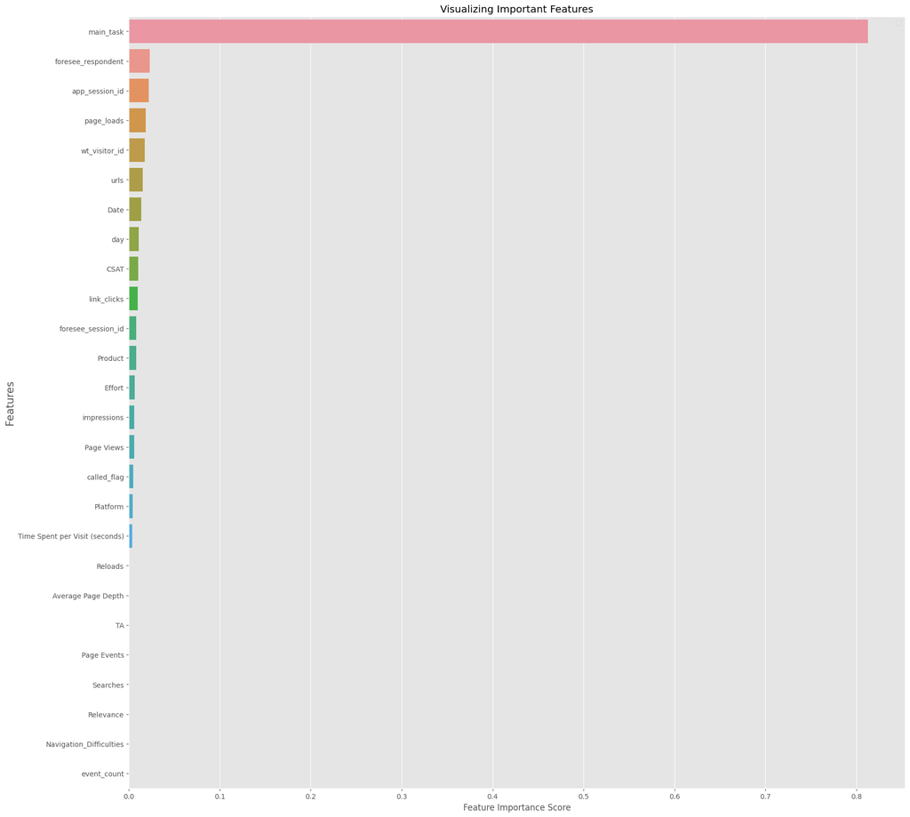

```python
X=data.drop(columns=['Survey_Category'])
y=data['Survey_Category']

rf = DecisionTreeClassifier()
rf.fit(X, y)
feature_imp = pd.Series(rf.feature_importances_,index=X.columns).sort_values(ascending=False)
plt.figure(figsize=(20, 20))
sns.barplot(x=feature_imp, y=feature_imp.index)
plt.xlabel('Feature Importance Score')
plt.ylabel('Features',fontsize=15)
plt.title("Visualizing Important Features")
plt.legend()
plt.show()
```

```python
feature_imp
```

```
main_task                         0.813015
foresee_respondent                0.022848
app_session_id                    0.021912
page_loads                        0.018799
wt_visitor_id                     0.017658
urls                              0.015162
Date                              0.013447
day                               0.010790
CSAT                              0.010278
link_clicks                       0.009650
foresee_session_id                0.008142
Product                           0.008073
Effort                            0.006268
impressions                       0.005816
Page Views                        0.005807
called_flag                       0.004703
Platform                          0.003998
Time Spent per Visit (seconds)    0.003635
Reloads                           0.000000
Average Page Depth                0.000000
TA                                0.000000
Page Events                       0.000000
Searches                          0.000000
Relevance                         0.000000
Navigation_Difficulties           0.000000
event_count                       0.000000
dtype: float64
```

### Features Importance with respect to Platform

```
No artists with labels found to put in legend.  Note that artists whose label start with an underscore are ignored when legend() is called with no argument.
```

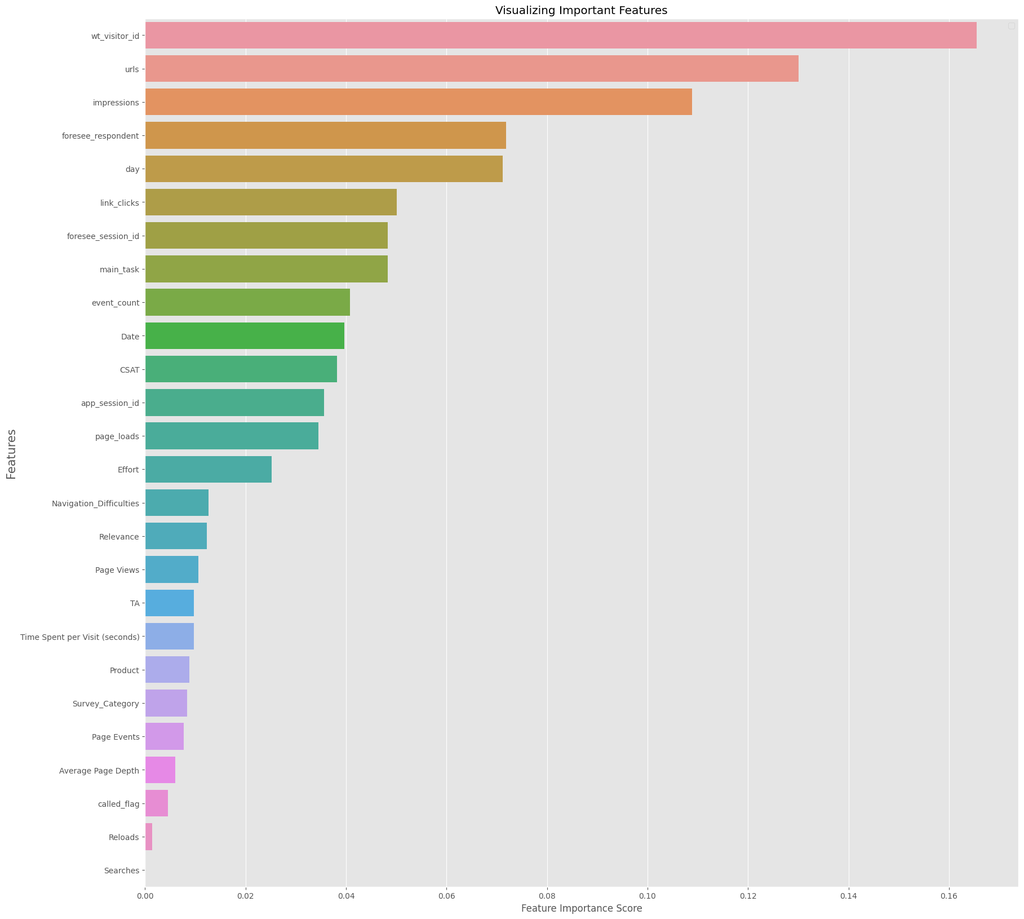

```python
X=data.drop(columns=['Platform'])
y=data['Platform']

rf = DecisionTreeClassifier()
rf.fit(X, y)
feature_imp = pd.Series(rf.feature_importances_,index=X.columns).sort_values(ascending=False)
plt.figure(figsize=(20, 20))
sns.barplot(x=feature_imp, y=feature_imp.index)
plt.xlabel('Feature Importance Score')
plt.ylabel('Features',fontsize=15)
plt.title("Visualizing Important Features")
plt.legend()
plt.show()
```

```python
feature_imp
```

```
wt_visitor_id                     0.165552
urls                              0.130035
impressions                       0.108916
foresee_respondent                0.071842
day                               0.071128
link_clicks                       0.050132
foresee_session_id                0.048268
main_task                         0.048257
event_count                       0.040818
Date                              0.039635
CSAT                              0.038248
app_session_id                    0.035613
page_loads                        0.034469
Effort                            0.025165
Navigation_Difficulties           0.012627
Relevance                         0.012346
Page Views                        0.010610
TA                                0.009718
Time Spent per Visit (seconds)    0.009672
Product                           0.008874
Survey_Category                   0.008409
Page Events                       0.007743
Average Page Depth                0.006002
called_flag                       0.004530
Reloads                           0.001393
Searches                          0.000000
dtype: float64
```

```python
data2=data1[data1['TA']=='Yes']
```

```python
dat = data2[['main_task', "page_loads",'Reloads']].groupby(['page_loads', 'main_task'])[['Reloads']].sum().sort_values(by = 'Reloads', ascending=False).head(50)
dat = dat.groupby(level=0).apply(lambda x: 100 * x / float(x.sum())).sort_values(by = 'main_task', ascending=False).style.background_gradient(cmap='BuGn')
dat
```

| page_loads | main_task | Reloads |
| --- | --- | --- |
| 3.000000 | View current bill | 91.684211 |
| 10.000000 | View current bill | 48.837209 |
| 14.000000 | View current bill | 40.322581 |
| 231.000000 | View current bill | 100.000000 |
| 16.000000 | View current bill | 42.056075 |
| 35.000000 | Update payment method | 51.807229 |
| 156.000000 | Set up or manage Access ID/website profile (includes linking/unlinking accounts) | 100.000000 |
| 24.000000 | Set up or manage Access ID/website profile (includes linking/unlinking accounts) | 59.233449 |
| 2.000000 | Request a wireless device return or check the status of a previous return request | 100.000000 |
| 9.000000 | Other | 31.659389 |
| 7.000000 | Other | 46.606335 |
| 3.000000 | Other | 8.315789 |
| 12.000000 | Other | 42.978723 |
| 20.000000 | Other | 45.818182 |
| 19.000000 | Make a payment | 100.000000 |
| 6.000000 | Make a payment | 100.000000 |
| 22.000000 | Make a payment | 100.000000 |
| 25.000000 | Make a payment | 100.000000 |
| 4544.000000 | Make a payment | 100.000000 |
| 17.000000 | Make a payment | 100.000000 |
| 31.000000 | Make a payment | 100.000000 |
| 27.000000 | Make a payment | 100.000000 |
| 30.000000 | Make a payment | 100.000000 |
| 36.000000 | Make a payment | 100.000000 |
| 35.000000 | Make a payment | 48.192771 |
| 26.000000 | Make a payment | 41.428571 |
| 10.000000 | Make a payment | 51.162791 |
| 9.000000 | Make a payment | 29.039301 |
| 14.000000 | Make a payment | 59.677419 |
| 275.000000 | Make a payment | 100.000000 |
| 13.000000 | Make a payment | 100.000000 |
| 20.000000 | Make a payment | 54.181818 |
| 5.000000 | Make a payment | 100.000000 |
| 28.000000 | Make a payment | 100.000000 |
| 12.000000 | Make a payment | 57.021277 |
| 18.000000 | Make a payment | 100.000000 |
| 21.000000 | Make a payment | 100.000000 |
| 16.000000 | Make a payment | 57.943925 |
| 11.000000 | Make a payment | 100.000000 |
| 15.000000 | Make a payment | 100.000000 |
| 23.000000 | Make a payment | 100.000000 |
| 7.000000 | Make a payment | 53.393665 |
| 24.000000 | Make a payment | 40.766551 |
| 8.000000 | Make a payment | 100.000000 |
| 92.000000 | Check usage | 100.000000 |
| 26.000000 | Check usage | 58.571429 |
| 133.000000 | Check usage | 100.000000 |
| 9.000000 | Check usage | 39.301310 |
| 40.000000 | Check usage | 100.000000 |
| 54.000000 | Check usage | 100.000000 |